# FinalProjectJulia

Julia Dawson, (copied from Sauyma Singh)

7/30/2020

## Stat 420: Final Project; Team Illinois (Saumya Singh, Joe Stewart, Julia Dawson)

Data is from https://www.countyhealthrankings.org/explore-health-rankings/rankings-data-documentation.

## Data Cleaning:

1. Read Excel file of County Data. Merge data from two sheets.
2. The team chose to keep variables that contained rates and to drop race demographics.
3. Drop columns with too many NA’s (more than our result YPLLRate). Out of 92 variables and 3141 observations we were left with 71 variables and 2333 observations.
4. Convert factor variables.
5. Add short names.

## Test Statistics that we used:

**adjusted R-squared** is a modified version of R-squared that has been adjusted for the number of predictors in the model. The adjusted R-squared increases only if the new term improves the model more than would be expected by chance. It decreases when a predictor improves the model by less than expected by chance.

**LOOCV RMSE**: leave-one out cross-validated RMSE allows us to check for overfitting.

**Correlation Coefficients** **Partial Correlation Coefficients**

**Shapiro-Wilk Test**: Shapiro test assesses the normality of errors. The null hypothesis assumes data were sampled from a normal distribution. A small p-value rejects the null hypothesis.

**Breusch-Pagan-Godfrey Test**: https://www.statisticshowto.com/breusch-pagan-godfrey-test/ Heteroscedastic data. … Heteroscedasticity means “differently scattered”; this is opposite to homoscedastic, which means “same scatter.” Homoscedasticity in regression is an important assumption; if the assumption is violated, you won’t be able to use regression analysis. If bptest gives a very small p-value so we reject the null hypothesis of constant variance.

**Durbin-Watson**: https://www.statisticshowto.com/durbin-watson-test-coefficient dwtest p — p-value of test p-value of the test, returned as a numeric value. dwtest tests whether the residuals are uncorrelated, against the alternative that autocorrelation exists among the residuals. A small p-value indicates that the residuals are autocorrelated. 0 to < 2 is positive autocorrelation. >2 to 4 is negative autocorrelation. Test statistics between 1.5 and 2.5 are relatively normal. The null hypothesis for dwtest is no first order correlation exists. Our p-value is higher than alpha 0.05 so we cannot reject the null hypothesis.

## Model Search:

- Result selection: We chose YPLLRate as our response variable. YPLLRate had the most highly correlated predictors. YPLL is the years of potential life lost before age 75 per 100,000 population (age-adjusted). YPLLRate is a measure of premature death and is used on an interactive site https://www.countyhealthrankings.org/explore-health-rankings to allow people to compare their State and County to others. The statement is on their home page is interesting… *“The annual Rankings provide a revealing snapshot of how health is influenced by where we live, learn, work, and play. They provide a starting point for change in communities.”* . Data is gathered from a variety of sources to create a model for comparison between States and Counties (https://www.countyhealthrankings.org/explore-health-rankings/measures-data-sources/2020-measures).

**Predictor selection:** + Predictors were chosen if; - they had some correlation with result (YPLLRate). - their partial correlation with result (YPLLRate) was high while controlling for the other model predictors. - they showed up in several large automatically generated models - they seemed representatives of factor we thought could be significant

- Predictors were eliminated one by one if:
  - they had high p-values in a model
  - removal had good or low affect on adjusted R-squared and LOOCV-RMSE
  - predictor was highly correlated with another predictor in the model.
- Automatic Model builds that were used for comparison:
  - Additive model all and backward AIC
  - Multiplicative model all and backward AIC
  - regsubsets all possible models (tried this but it ran for three days and crashed the computer)

|  | Plain Model | BoxCox_No_Outliers |
| --- | --- | --- |
| adjusted R-squared | 0.960 | 0.972 |
| LOOCV RMSE | 479.697 | 17.501 |
| Std Dev | 2367.259 | 109.497 |
| LOOCV - Std Dev Ratio | 0.203 | 0.160 |
| Shapiro P-value | 0.000 | 0.339 |
| BP P-value | 0.000 | 0.000 |
| BP value | 301.861 | 131.360 |
| BoxCox lambda | 0.700 | 1.200 |
| Number of Coef | 24.000 | 24.000 |

## Try adding weights to the model

**Conclusion: Weights slightly worsened the model. Weights lowered adjusted R-squaired, raised LOOCV RMSE and lowered the Shapiro p-value.**

```r
formula(mdljdwt)
```

```
## YPLLRate^lmda_mdljd ~ HealthPoorPct + FoodEnvirIX + PhysInactPct +
##     PhysPrimCareRate + MammAnnualPct + Income20thpcntl + IncomeRatio +
##     SocsAssRate + InjuryDeathRate + HousSvrProbPct + HousInadFacil +
##     LifeExpect + DeathAgeAdjRate + VaccinatedPct + IncHousehldMedian +
##     PopGE65Pct + PopNativePct + PopPacificPct + EnglishNotProfPct +
##     PopRuralPct + PopGE65Pct:DeathAgeAdjRate + HealthPoorPct:PopFemalePct +
##     LBWPct:IncHousehldMedian
```

|  | with weights | BoxCox_No_Outliers |
| --- | --- | --- |
| adjusted R-squared | 0.967 | 0.972 |
| LOOCV RMSE | 20.537 | 17.501 |
| Std Dev | 109.497 | 109.497 |
| LOOCV - Std Dev Ratio | 0.188 | 0.160 |
| Shapiro P-value | 0.016 | 0.339 |
| BP P-value | 0.000 | 0.000 |
| BP value | 131.360 | 131.360 |
| BoxCox lambda | 0.800 | 1.200 |
| Number of Coef | 24.000 | 24.000 |

## Try scaling the model predictors

**Conclusion: Scaling the predictors slightly worsened the model. It slightly lowered adjusted R-squaired, raised LOOCV RMSE. But on the good side it raised Shapiro p-value and slightly lowered BP value.**

```r
formula(mdljdsc)
```

```
## YPLLRate^lmda_mdljd ~ HealthPoorPct + FoodEnvirIX + PhysInactPct +
##     PhysPrimCareRate + MammAnnualPct + Income20thpcntl + IncomeRatio +
##     SocsAssRate + InjuryDeathRate + HousSvrProbPct + HousInadFacil +
##     LifeExpect + DeathAgeAdjRate + VaccinatedPct + IncHousehldMedian +
##     PopGE65Pct + PopNativePct + PopPacificPct + EnglishNotProfPct +
##     PopRuralPct + PopGE65Pct:DeathAgeAdjRate + HealthPoorPct:PopFemalePct +
##     LBWPct:IncHousehldMedian
```

|  | Scaled Predictors | BoxCox_No_Outliers |
| --- | --- | --- |
| adjusted R-squared | 0.969 | 0.972 |
| LOOCV RMSE | 18.338 | 17.501 |
| Std Dev | 109.497 | 109.497 |
| LOOCV - Std Dev Ratio | 0.167 | 0.160 |
| Shapiro P-value | 0.522 | 0.339 |
| BP P-value | 0.000 | 0.000 |
| BP value | 129.171 | 131.360 |
| BoxCox lambda | 1.200 | 1.200 |
| Number of Coef | 24.000 | 24.000 |

**versus Residuals Plot**

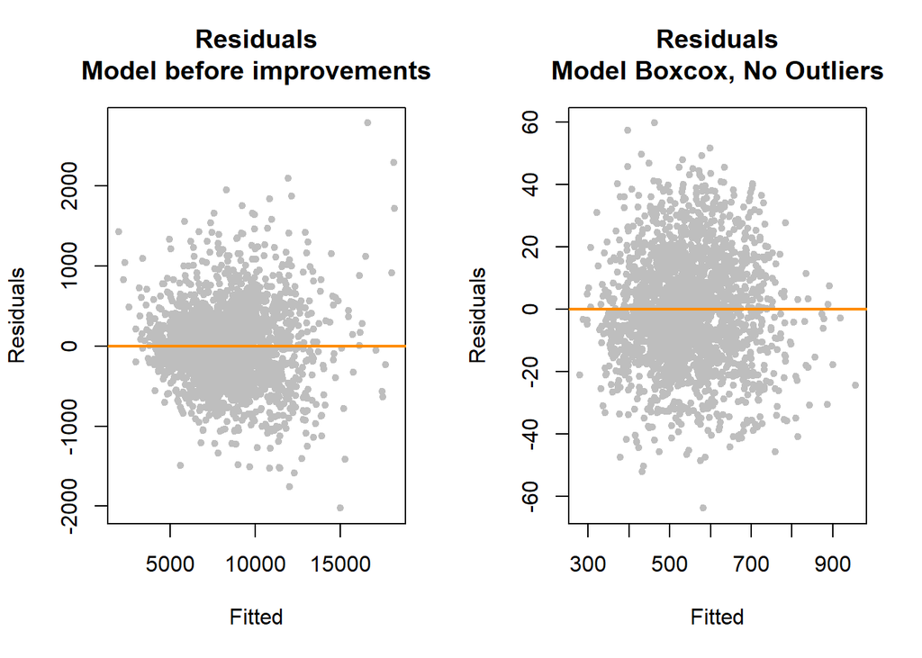

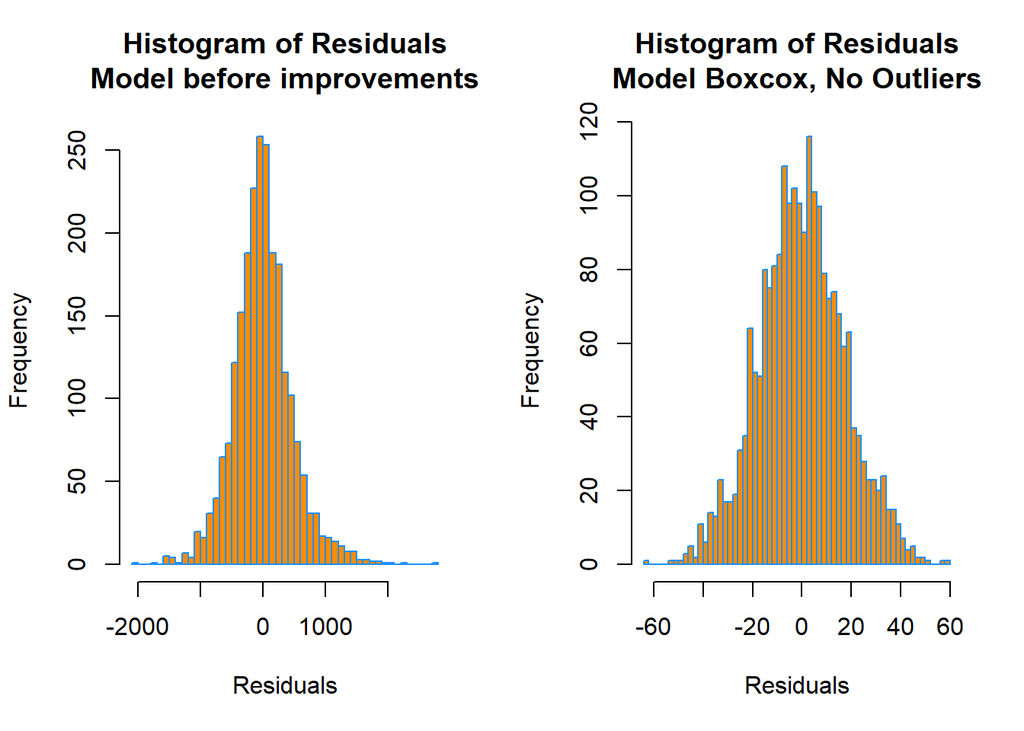

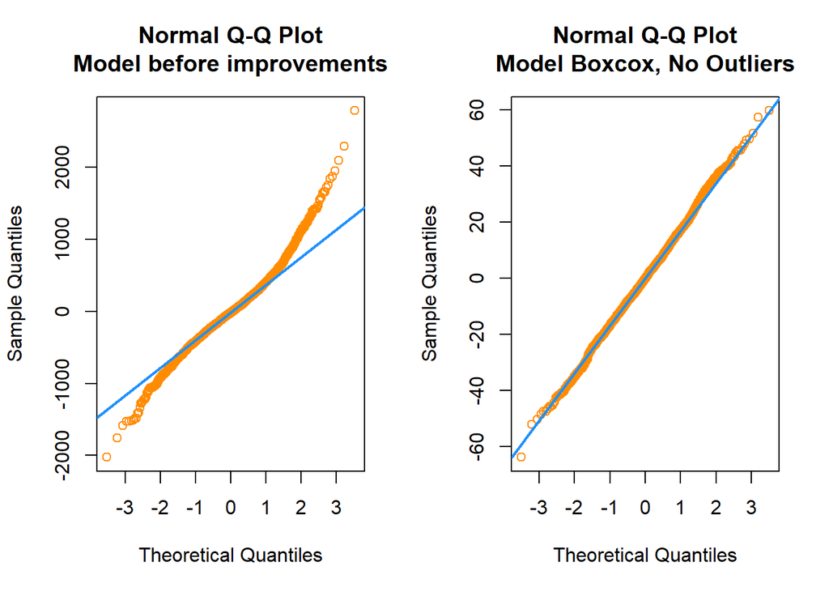

## BOX-COX transformation on response, before and after

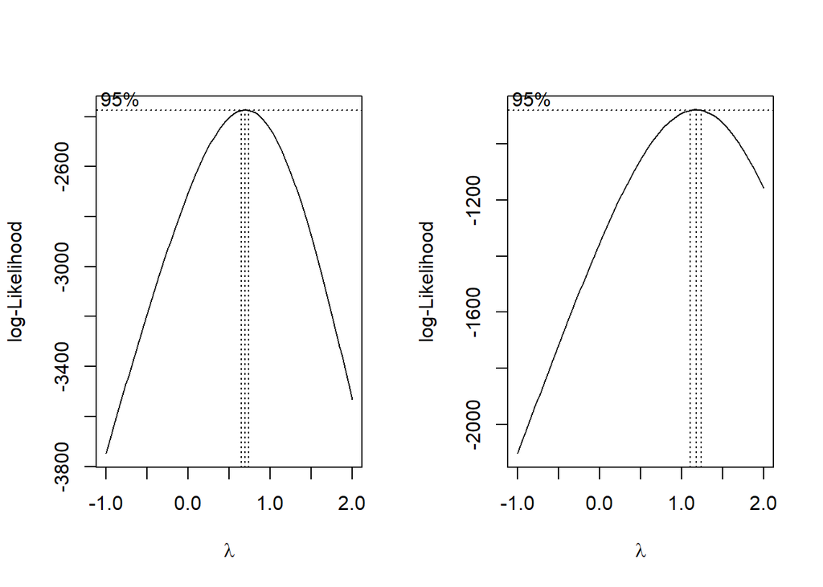

## Comparison of Weights, Scaling, and original BoxCox, No Outliers

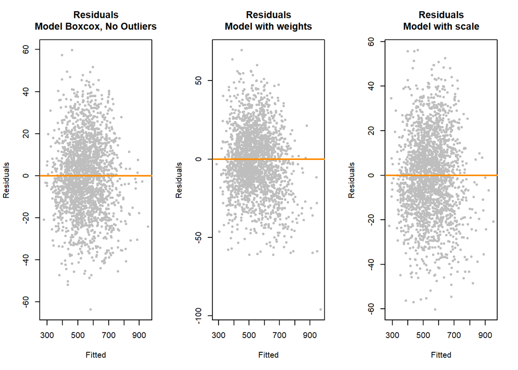

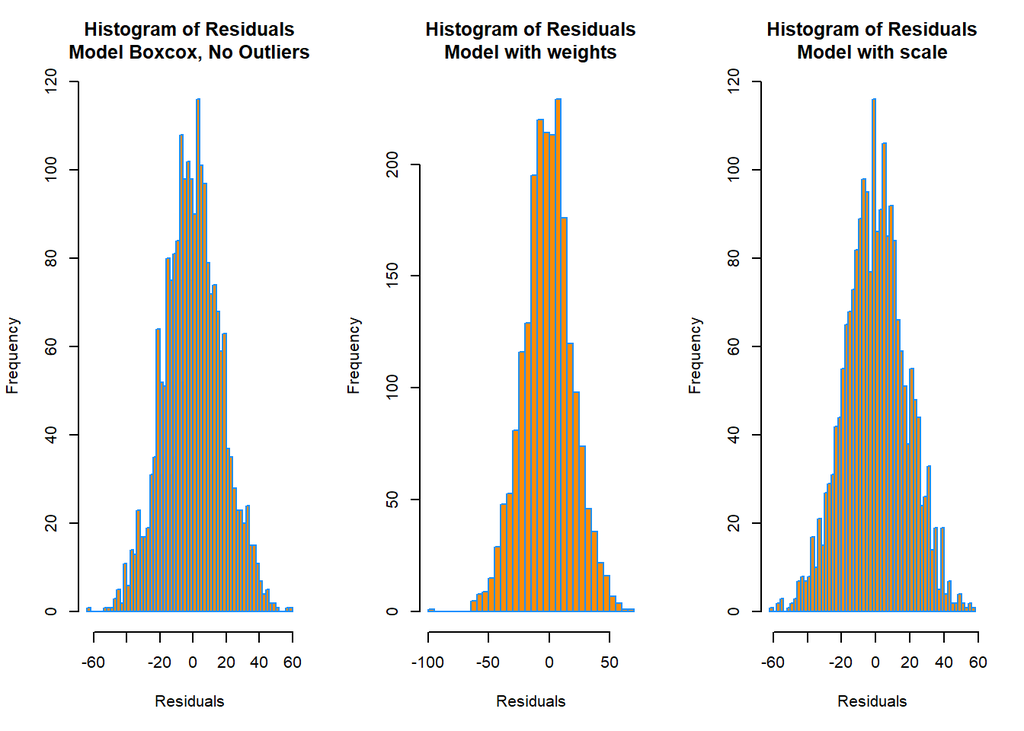

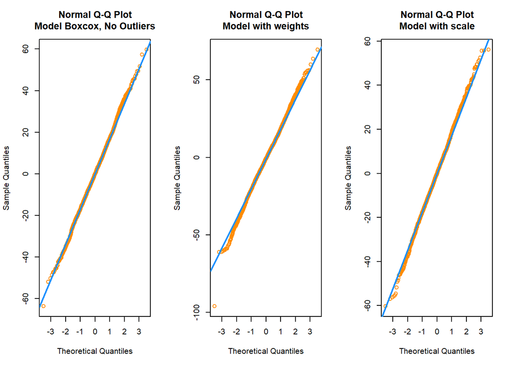

## Train-Test logic: Split Data into Train and Test and Compare RMSE and percent error:

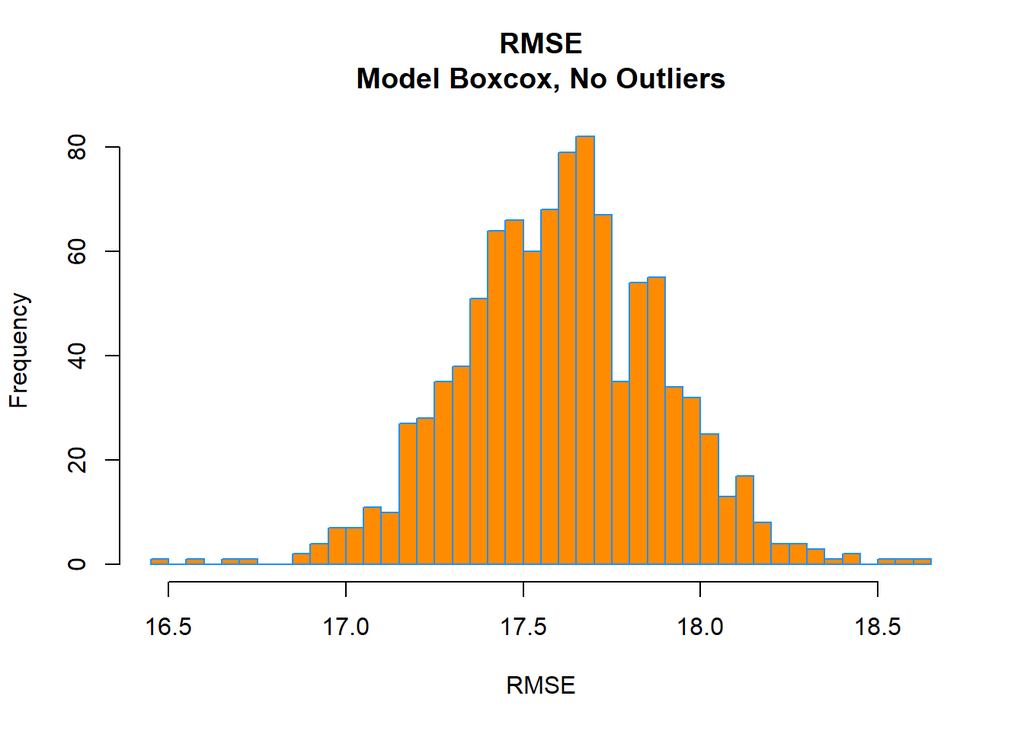

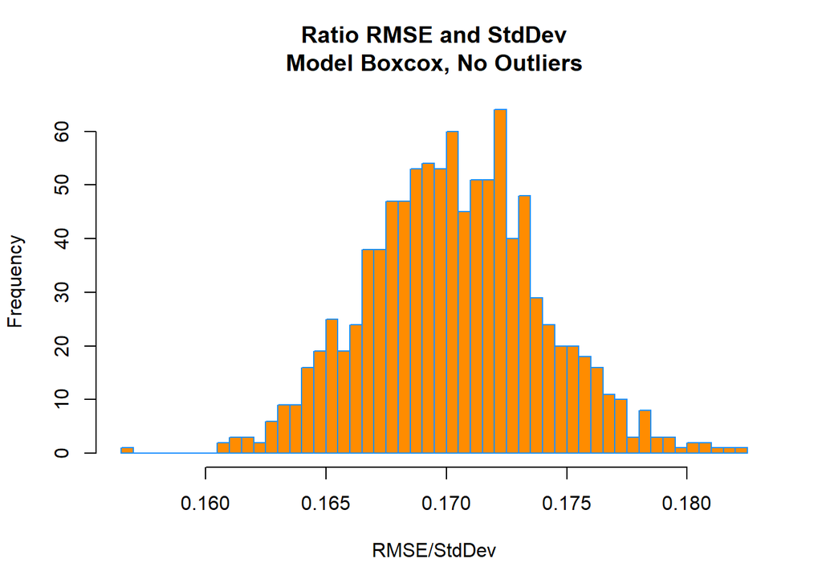

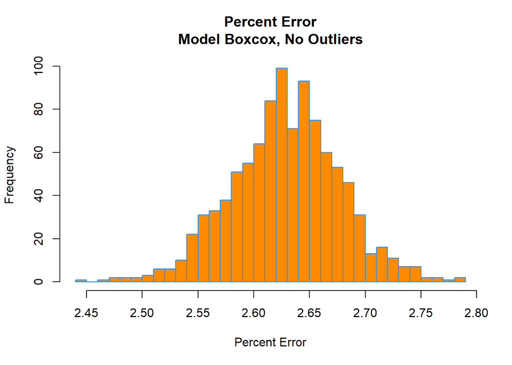

```
## [1] 2.63
```

```
## [1] 2.63
```

```
## [1] 0.17
```

```
## [1] 0.17
```

## Correlation matrix (to inform predictor selection and model tuning):

- Correlation matrix is generated between all data elements.
- Correlation matrix is flattened to pairs and written to an excel spreadsheet for later use.

## Partial Correlation Coefficients and other comparisons: To aid in predictor selection:

- Partial correlation coefficients were calculated between all possible predictors and our result (YPLLRate).
- Partial correlation coefficients were also calculated between some other data elements to see if they might be viable or better results (DeathAgeAdjRate, LifeExpect, Income20thpcntl, UninsAdultPct, LunchFreeReducedPct, PopGE65Pct). None of them had as many highly correlated predictors so we remained with YPLLRate as our response.
- Individual plots were done of each predictor against YPLLRate. Notes were made as to which transformations improved each individual predictors residuals versus fitted. Highly correlated predictors to the individual predictor where checked to see if an interaction term improved the residuals versus fitted plot and was noted. This data was later used in model tuning decisions.